# *Timer* for Hugo

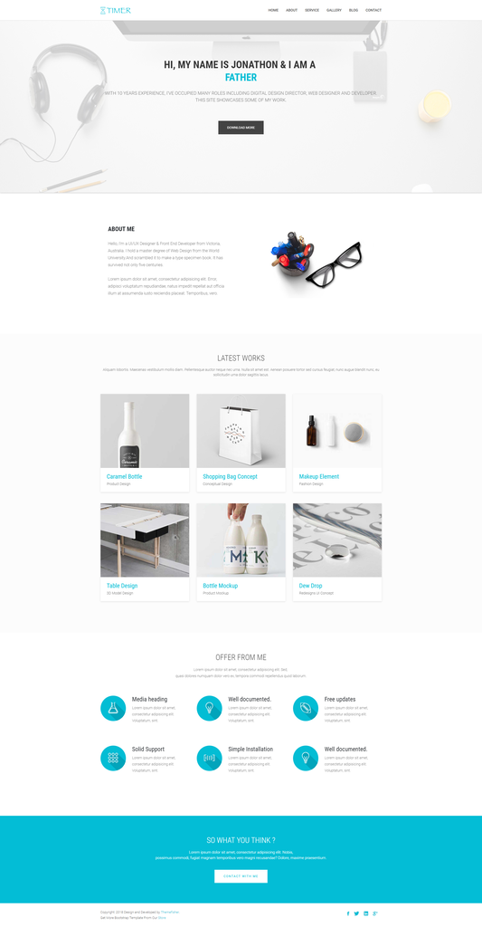

screenshot

Timer is bootstrap based HTML5 responsive multipage agency template built using HTML5/CSS3 features and suitable for creative companies, agencies, and freelancers which need a professional way to showcase their projects, services, and sell their products.

Timer has been designed and built with a ‘user first’ approach; Timer offers a beautifully elegant, simple and well-spaced template that follows the principles of design. This flexible template uses fresh and clean design and allows to change it looks to your liking in one click.

## Usage

Create a new Hugo site by typing

```
  $ hugo new site <SITENAME>
```

Then clone this repository:

```
  $ cd <SITENAME>/themes
  $ git clone https://github.com/themefisher/timer-hugo
```

Now take a look at the exampleSite folder and you’re ready to go!

## License

This Template is released under [Creative Commons Attribution 3.0 (CC-BY-3.0) License](https://creativecommons.org/licenses/by/3.0/) If you want to remove the credit simply make a [donation](https://www.paypal.me/Themefisher), so that we can run our contribution to hugo community.

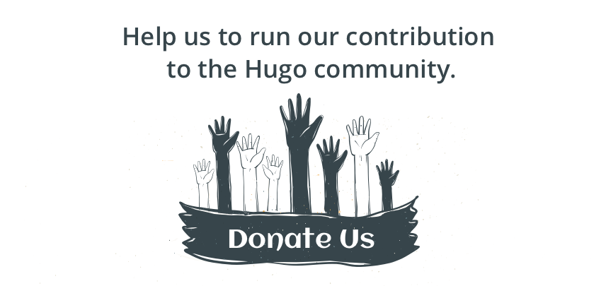

## About Themefisher

[Themefisher](https://themefisher.com/) has been creating beautiful free and premium Bootstrap and HTML5 templates since 2014. Visit us at https://themefisher.com/ to see other great-looking themes.

## We are available for Hiring of your next HUGO project. Drop Us a mail themefisher@gmail.com